# ( Ford Gobike Data Analysis )

## by (Omar Reda Hosseny)

## Investigation Overview

> In this presentation, I wanted to look at the characteristics of trips that could be affect trips numbers and duration  
> The main focus was on start hour,start day of week , member age ,user type and member gender

## Dataset Overview

> the dataset contains 183412 trip with features vary from trip information such as trip duration and start time  
> and member information such as birth year, gender,usertype

## ( Distribution of Trip duration)

> duration of trip has a right skewed distribution so the duration of the trips is increased  
> most of trip duration is less than 1800 seconds (half an hour) with 96.3%  
> there are too few trips which durations are more than 3600 seconds(one hour) with 0.9%

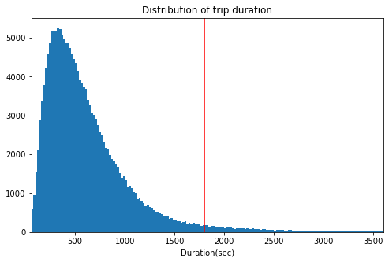

## (Distribution of Member Age)

> the distribution of age is right skewed and most ages are between 20 and 45 years old  
> the most of our population are not retired yet and they are in work or still study

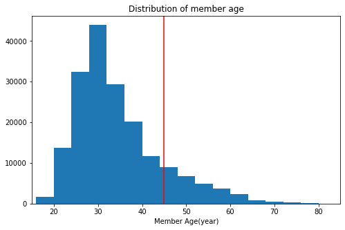

## (Percentage Of Each User Type)

> most of trips are made by subscriber members with percentage of 89.6%  
> while customers made only 10.4% of all trips

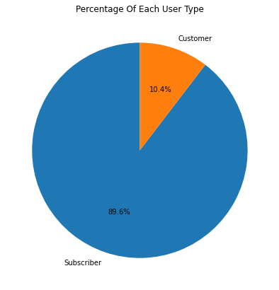

## (Percentage Of Each Gender In Our Data)

> most of trips are made by males members with percentage of 75.76%  
> while females made 22.27% of all trips and others made only 1.97% of all trips

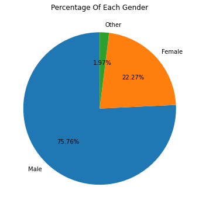

## (Effect Of Day Parts Accorrding To User Type On The Trip Duration)

> we found that long trips occur in morning and afternoon part of the day  
> and trip duration for customer are more than subscriber member for all parts of day

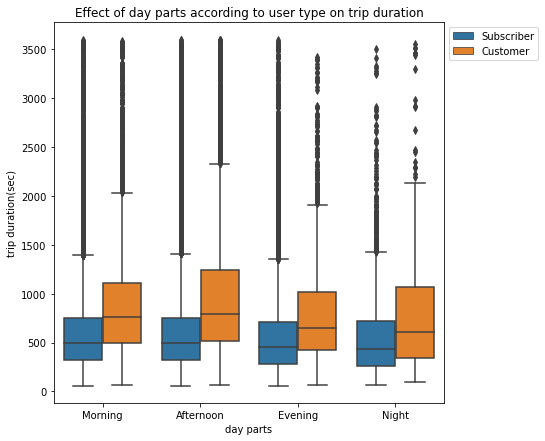

## (Effect Of Age Buckets Accorrding To Gender On The Trip Duration)

> we found that for all age buckets males make the faster trips  
> and other make the slowest trips  
> except for youth females make the slowest trips

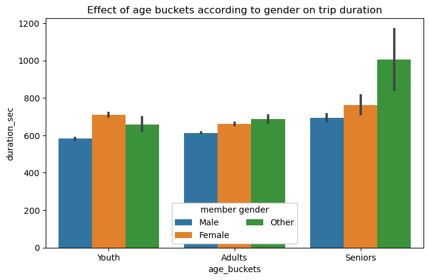

## (Effect Of Day Of Week According To Age Buckets On The Trip Duration)

> we found that long trips occur at the weekend days such as saturday and sunday  
> and for most days youth trips are faster and adults make slower trips while seniors make the slowest trips  
> except monday and thursday trips duration of adults and youth are close to each other

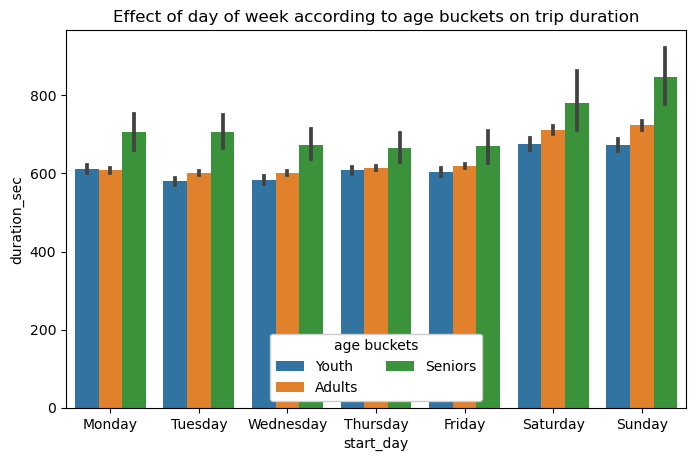